# National Greenhouse Gas Emissions Exploratory Analysis

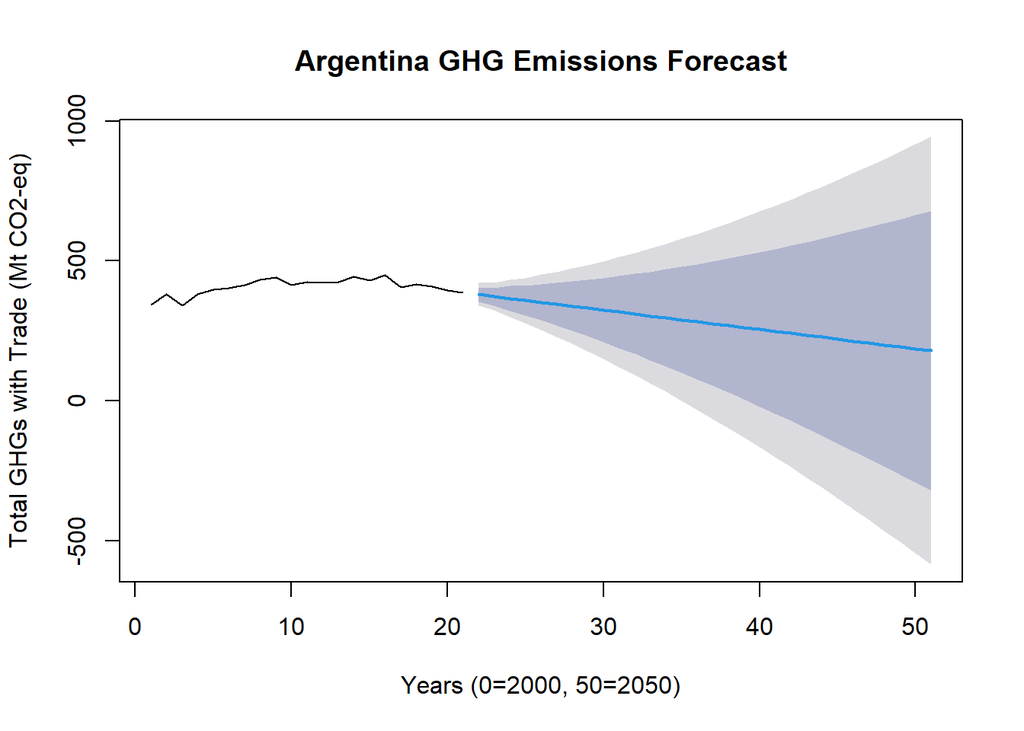

```
## $mean
## Time Series:
## Start = 22
## End = 51
## Frequency = 1
##  [1] 380.2893 372.3554 366.0485 358.7462 352.0528 344.9869 338.1489 331.1715
##  [9] 324.2794 317.3351 310.4227 303.4908 296.5709 289.6436 282.7208 275.7953
## [17] 268.8714 261.9465 255.0223 248.0976 241.1732 234.2487 227.3242 220.3997
## [25] 213.4752 206.5507 199.6262 192.7017 185.7772 178.8527
##
## $lower
## Time Series:
## Start = 22
## End = 51
## Frequency = 1
```

[output cut: 68 more lines]

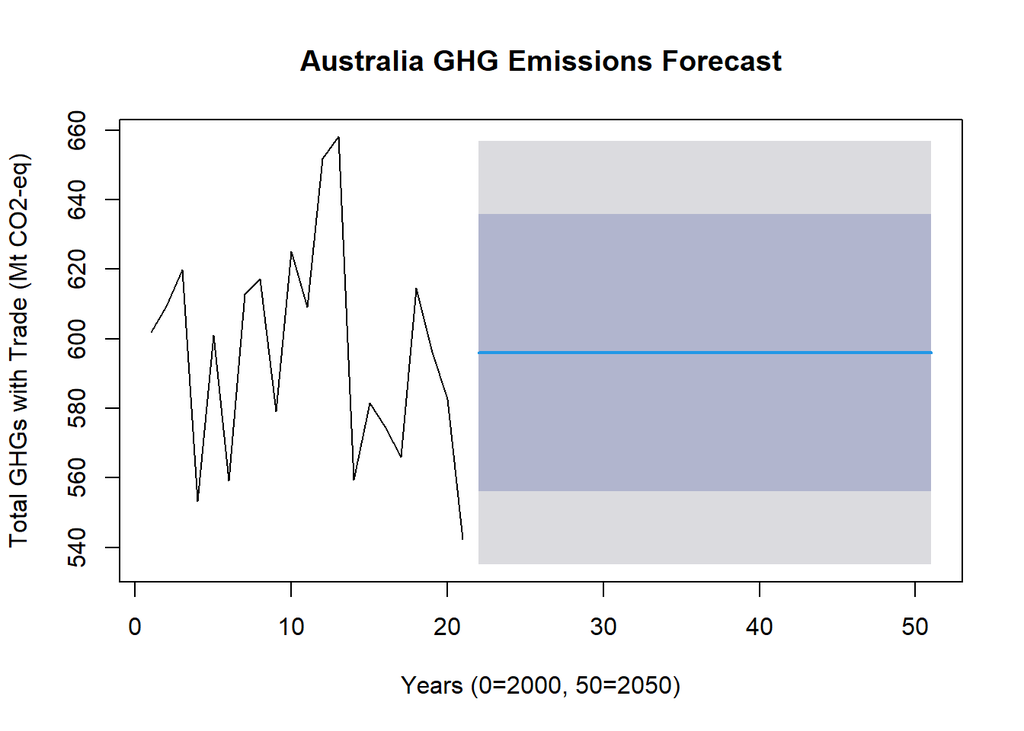

```
## $mean
## Time Series:
## Start = 22
## End = 51
## Frequency = 1
##  [1] 595.9693 595.9693 595.9693 595.9693 595.9693 595.9693 595.9693 595.9693
##  [9] 595.9693 595.9693 595.9693 595.9693 595.9693 595.9693 595.9693 595.9693
## [17] 595.9693 595.9693 595.9693 595.9693 595.9693 595.9693 595.9693 595.9693
## [25] 595.9693 595.9693 595.9693 595.9693 595.9693 595.9693
##
## $lower
## Time Series:
## Start = 22
## End = 51
## Frequency = 1
```

[output cut: 68 more lines]

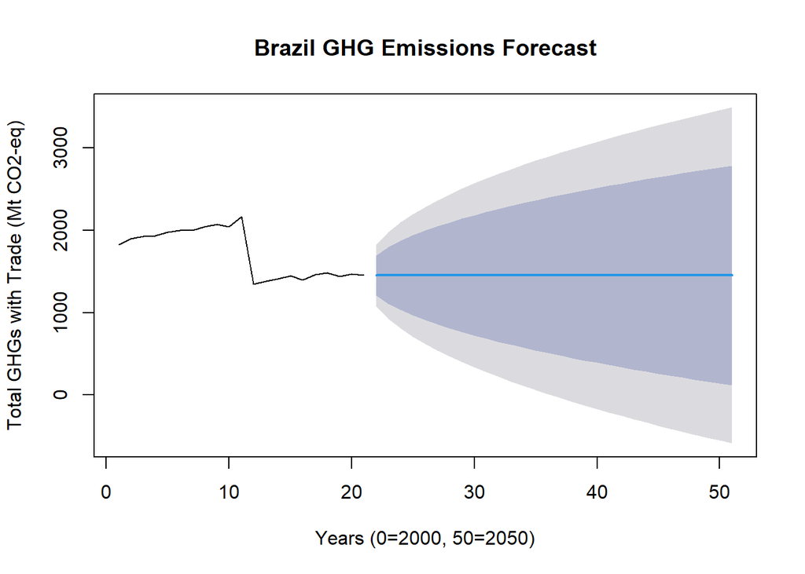

```
## $mean
## Time Series:
## Start = 22
## End = 51
## Frequency = 1
##  [1] 1452.7 1452.7 1452.7 1452.7 1452.7 1452.7 1452.7 1452.7 1452.7 1452.7
## [11] 1452.7 1452.7 1452.7 1452.7 1452.7 1452.7 1452.7 1452.7 1452.7 1452.7
## [21] 1452.7 1452.7 1452.7 1452.7 1452.7 1452.7 1452.7 1452.7 1452.7 1452.7
##
## $lower
## Time Series:
## Start = 22
## End = 51
## Frequency = 1
##          80%         95%
```

[output cut: 67 more lines]

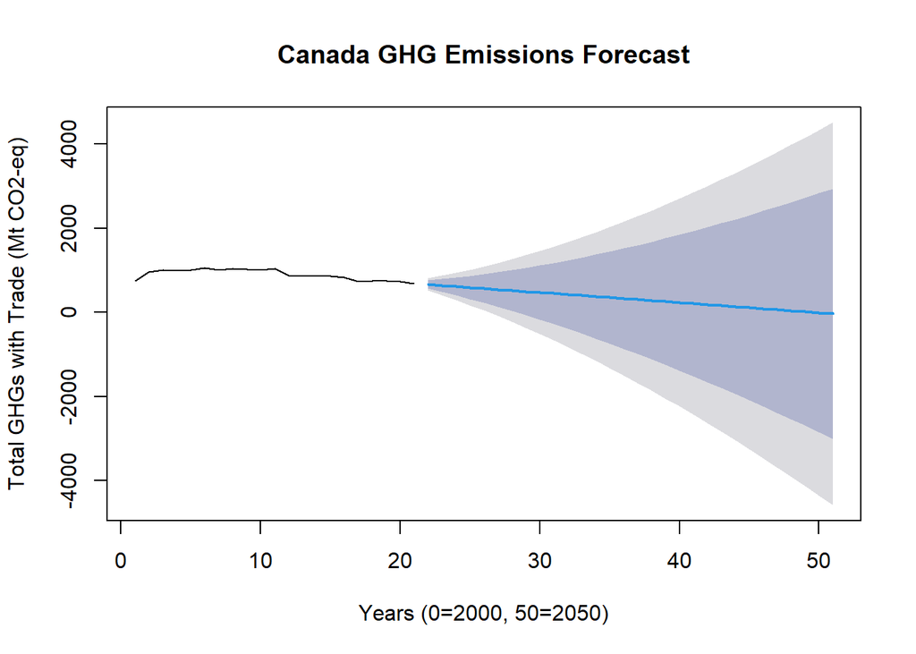

```
## $mean
## Time Series:
## Start = 22
## End = 51
## Frequency = 1
##  [1] 665.827025 641.697051 617.567076 593.437101 569.307127 545.177152
##  [7] 521.047178 496.917203 472.787228 448.657254 424.527279 400.397304
## [13] 376.267330 352.137355 328.007381 303.877406 279.747431 255.617457
## [19] 231.487482 207.357507 183.227533 159.097558 134.967584 110.837609
## [25]  86.707634  62.577660  38.447685  14.317710  -9.812264 -33.942239
##
## $lower
## Time Series:
## Start = 22
## End = 51
```

[output cut: 69 more lines]

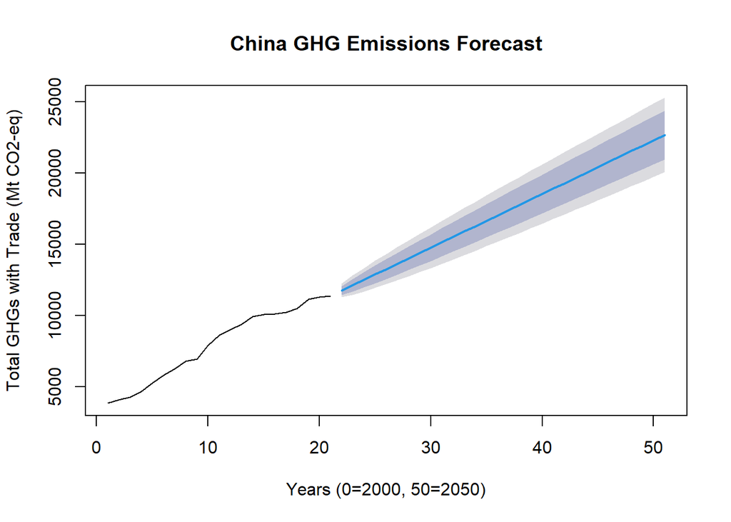

```
## $mean
## Time Series:
## Start = 22
## End = 51
## Frequency = 1
##  [1] 11742.27 12118.81 12495.34 12871.88 13248.41 13624.95 14001.49 14378.02
##  [9] 14754.56 15131.09 15507.63 15884.16 16260.70 16637.23 17013.77 17390.30
## [17] 17766.84 18143.37 18519.91 18896.44 19272.98 19649.51 20026.05 20402.58
## [25] 20779.12 21155.65 21532.19 21908.72 22285.26 22661.79
##
## $lower
## Time Series:
## Start = 22
## End = 51
## Frequency = 1
```

[output cut: 68 more lines]

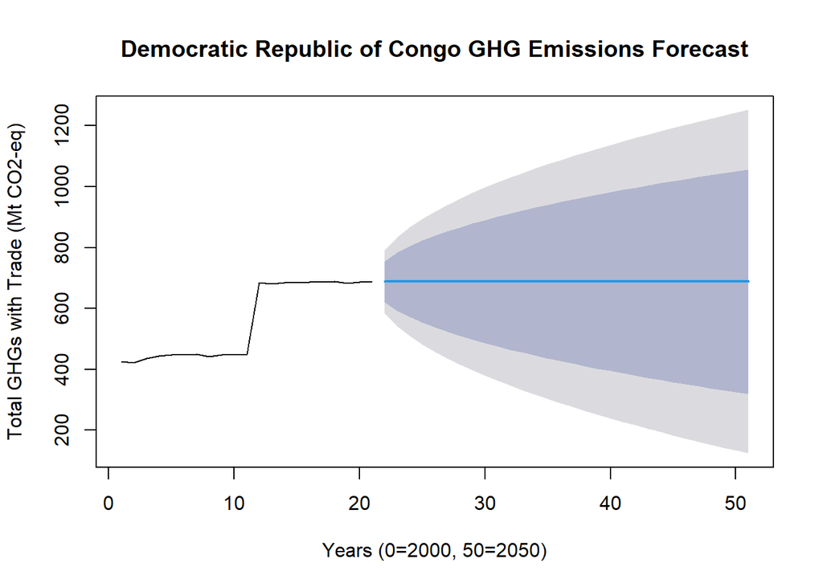

```
## $mean
## Time Series:
## Start = 22
## End = 51
## Frequency = 1
##  [1] 688.06 688.06 688.06 688.06 688.06 688.06 688.06 688.06 688.06 688.06
## [11] 688.06 688.06 688.06 688.06 688.06 688.06 688.06 688.06 688.06 688.06
## [21] 688.06 688.06 688.06 688.06 688.06 688.06 688.06 688.06 688.06 688.06
##
## $lower
## Time Series:
## Start = 22
## End = 51
## Frequency = 1
##         80%      95%
```

[output cut: 67 more lines]

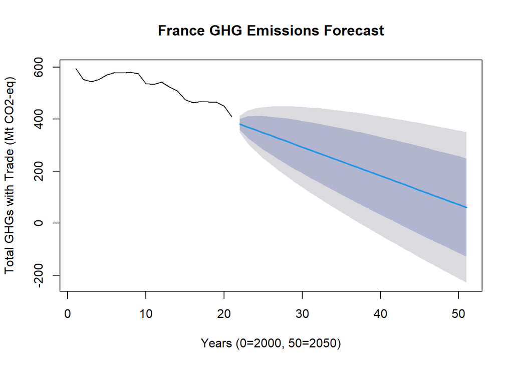

```
## $mean
## Time Series:
## Start = 22
## End = 51
## Frequency = 1
##  [1] 381.13165 370.09209 359.05253 348.01297 336.97341 325.93385 314.89429
##  [8] 303.85473 292.81517 281.77561 270.73605 259.69649 248.65693 237.61737
## [15] 226.57781 215.53825 204.49869 193.45913 182.41957 171.38000 160.34044
## [22] 149.30088 138.26132 127.22176 116.18220 105.14264  94.10308  83.06352
## [29]  72.02396  60.98440
##
## $lower
## Time Series:
## Start = 22
## End = 51
```

[output cut: 69 more lines]

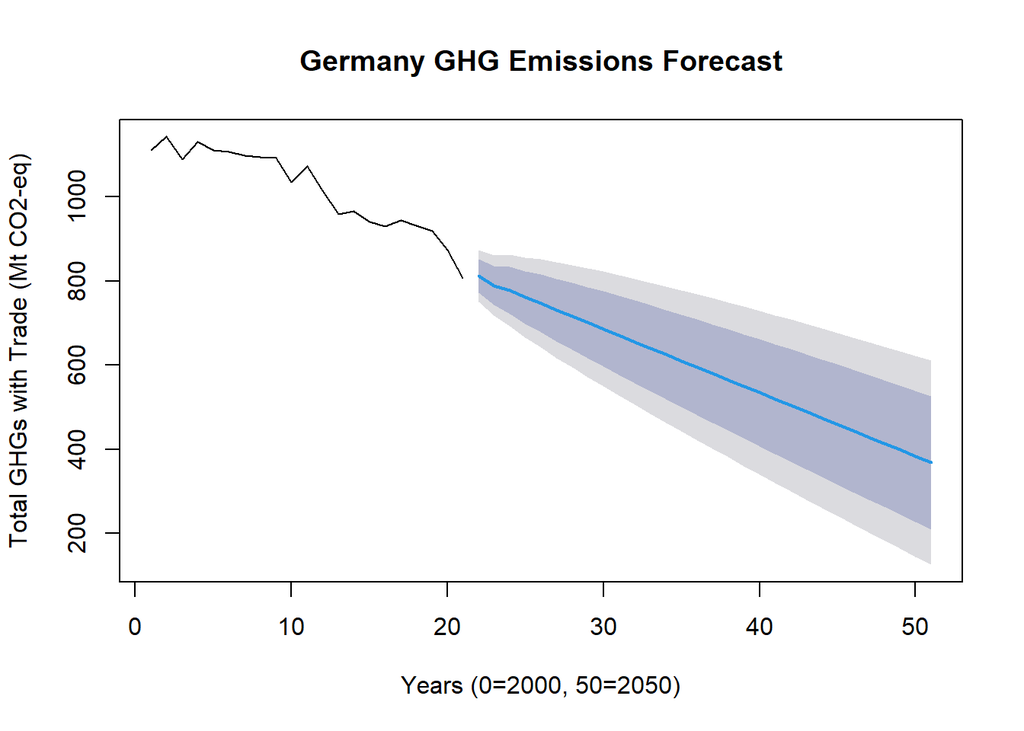

```
## $mean
## Time Series:
## Start = 22
## End = 51
## Frequency = 1
##  [1] 812.7453 789.3632 777.5504 761.1097 746.5202 731.1902 716.1564 701.0041
##  [9] 685.8992 670.7754 655.6591 640.5398 625.4218 610.3032 595.1848 580.0664
## [17] 564.9480 549.8296 534.7111 519.5927 504.4743 489.3559 474.2374 459.1190
## [25] 444.0006 428.8822 413.7638 398.6453 383.5269 368.4085
##
## $lower
## Time Series:
## Start = 22
## End = 51
## Frequency = 1
```

[output cut: 68 more lines]

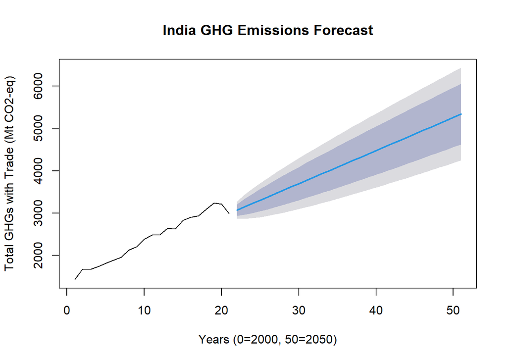

```
## $mean
## Time Series:
## Start = 22
## End = 51
## Frequency = 1
##  [1] 3071.304 3149.479 3227.653 3305.827 3384.001 3462.176 3540.350 3618.524
##  [9] 3696.698 3774.873 3853.047 3931.221 4009.395 4087.570 4165.744 4243.918
## [17] 4322.092 4400.267 4478.441 4556.615 4634.789 4712.964 4791.138 4869.312
## [25] 4947.486 5025.661 5103.835 5182.009 5260.183 5338.358
##
## $lower
## Time Series:
## Start = 22
## End = 51
## Frequency = 1
```

[output cut: 68 more lines]

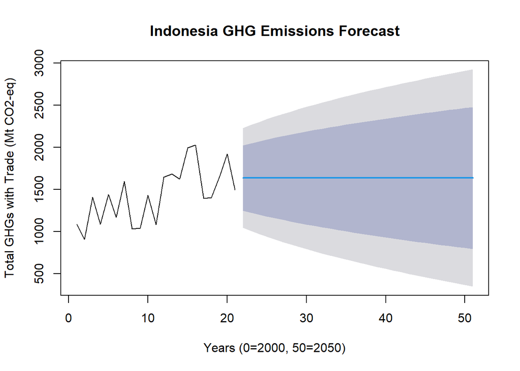

```
## $mean
## Time Series:
## Start = 22
## End = 51
## Frequency = 1
##  [1] 1635.609 1635.609 1635.609 1635.609 1635.609 1635.609 1635.609 1635.609
##  [9] 1635.609 1635.609 1635.609 1635.609 1635.609 1635.609 1635.609 1635.609
## [17] 1635.609 1635.609 1635.609 1635.609 1635.609 1635.609 1635.609 1635.609
## [25] 1635.609 1635.609 1635.609 1635.609 1635.609 1635.609
##
## $lower
## Time Series:
## Start = 22
## End = 51
## Frequency = 1
```

[output cut: 68 more lines]

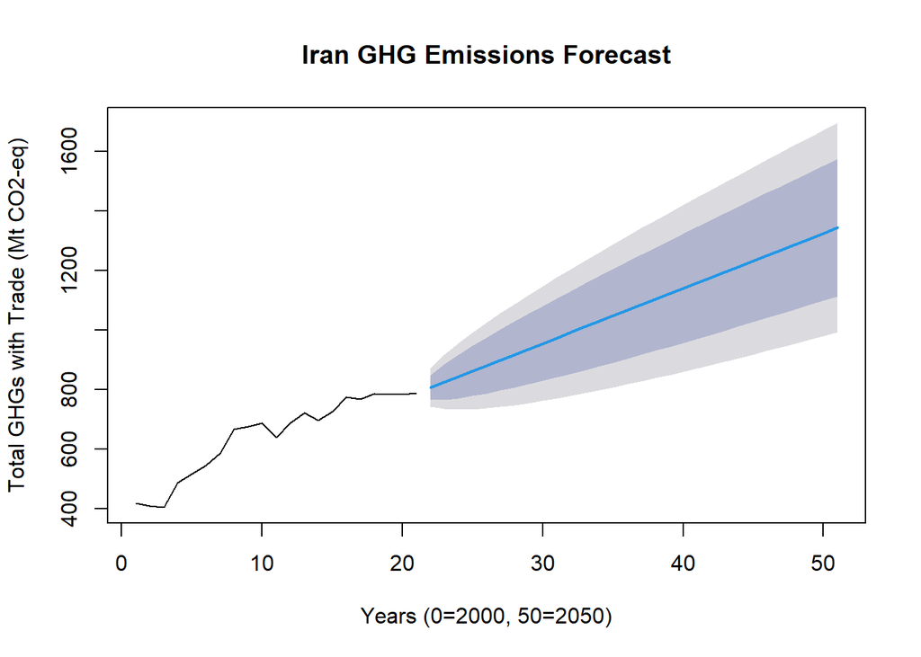

```
## $mean
## Time Series:
## Start = 22
## End = 51
## Frequency = 1
##  [1]  807.4295  825.9421  844.4546  862.9672  881.4797  899.9923  918.5048
##  [8]  937.0174  955.5299  974.0425  992.5550 1011.0676 1029.5801 1048.0927
## [15] 1066.6052 1085.1178 1103.6303 1122.1429 1140.6554 1159.1680 1177.6805
## [22] 1196.1931 1214.7056 1233.2182 1251.7307 1270.2433 1288.7558 1307.2684
## [29] 1325.7809 1344.2935
##
## $lower
## Time Series:
## Start = 22
## End = 51
```

[output cut: 69 more lines]

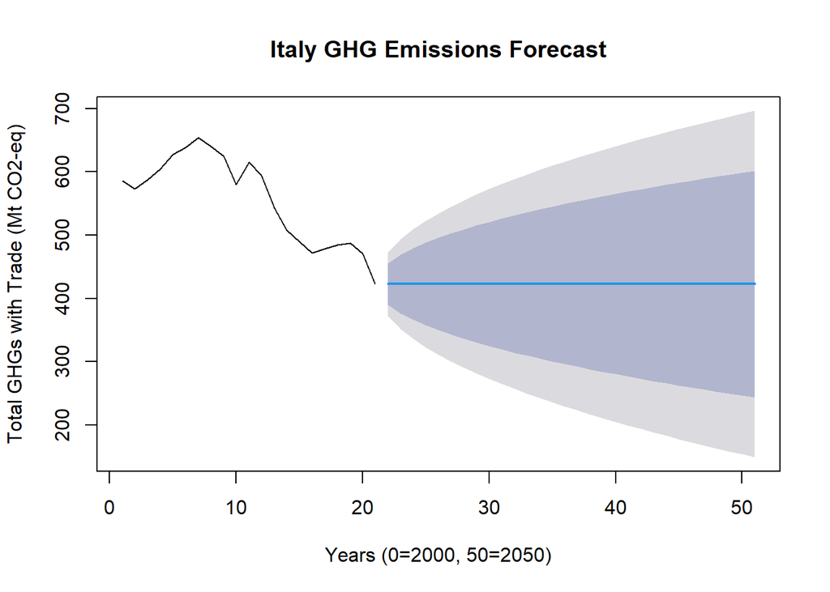

```
## $mean
## Time Series:
## Start = 22
## End = 51
## Frequency = 1
##  [1] 422.804 422.804 422.804 422.804 422.804 422.804 422.804 422.804 422.804
## [10] 422.804 422.804 422.804 422.804 422.804 422.804 422.804 422.804 422.804
## [19] 422.804 422.804 422.804 422.804 422.804 422.804 422.804 422.804 422.804
## [28] 422.804 422.804 422.804
##
## $lower
## Time Series:
## Start = 22
## End = 51
## Frequency = 1
```

[output cut: 68 more lines]

[8 more figures not shown]

```
## $mean
## Time Series:
## Start = 22
## End = 51
## Frequency = 1
##  [1] 214.825 214.825 214.825 214.825 214.825 214.825 214.825 214.825 214.825
## [10] 214.825 214.825 214.825 214.825 214.825 214.825 214.825 214.825 214.825
## [19] 214.825 214.825 214.825 214.825 214.825 214.825 214.825 214.825 214.825
## [28] 214.825 214.825 214.825
##
## $lower
## Time Series:
## Start = 22
## End = 51
## Frequency = 1
```

[output cut: 68 more lines]

```r
national_ghg_emissions_forecast2 <- national_ghg_emissions %>%
  filter(country %in% top_20_emitters$country & year >= 2000 & year <= 2020) %>%
  mutate(total_ghgs_with_trade = if_else(is.na(trade_co2),total_ghg, total_ghg + trade_co2))


for (country in unique(national_ghg_emissions_forecast2$country)) {
  country_data <- national_ghg_emissions_forecast2[national_ghg_emissions_forecast2$country == country, ]
  emissions_model <- auto.arima(country_data$total_ghgs_with_trade)
  emissions_forecasts <- forecast(emissions_model, h = 30)
  print(
    plot(emissions_forecasts,
         main = paste(country, "GHG Emissions Forecast"),
         xlab = "Years (0=2000, 50=2050)",
         ylab = "Total GHGs with Trade (Mt CO2-eq)")
  )
}
```

## Conclusions

Overall, the results of this analysis highlight the urgent need for greater action to address climate change and, in particular, with respect to GHG emissions reductions. Ultimately, while a few countries were identified as consistently reducing GHG emissions and increasing GDP on an annual basis over the course of the 2000-2020 time series, it was also observed that there are clear deficits when it comes to countries being on track to achieve net-zero by 2050.

Forecasts using an ARIMA model identified only two countries that are predicted to achieve net-zero by 2050 based on current trends - Canada and Timor-Leste, though it should be noted that not all countries were forecasted during this activity. However, forecasts were generated for each of the top 20 GHG emitting countries, based on cumulative emissions over the 2000-2020 time period. Of these top 20 emitters, only Canada was forecasted to achieve net-zero while just four other countries - Argentina, France, Germany, and the United Kingdom - are projected to reduce emissions over the 30-year horizon. Moreover, the top 20 emitting countries of China, India, Iran, Japan, and Saudi Arabia are forecasted to increase their emissions over the 30-year horizon.

These results, while limited due to the fact that the analyses were mainly restricted to the assessments of just a few parameters that measure national GHG emissions, GDP, and population, suggest that there are serious gaps towards the achievement of net-zero by 2050. Perhaps even more concerning is that several top 20 emitting countries are actually forecasted to increase their emissions. When it comes to the cases of China and India, the number two and three emitters globally, this even reflects comments made by leaders of the two countries. China’s president Xi Jinping stated that the country has the “[aim to have CO2 emissions peak before 2030 and achieve carbon neutrality before 2060](https://www.iea.org/reports/an-energy-sector-roadmap-to-carbon-neutrality-in-china)” while [Indian Prime Minister Narenda Modi has targeted 2070 as the country’s target for net-zero](https://climateactiontracker.org/countries/india/net-zero-targets/). While both indicate there may be emissions reduction efforts in the future, they reflect a relative lack of action across the world regarding emissions reduction efforts.

Nevertheless, there are a few countries that, at the very least, show indications of taking the lead towards the achievement of net-zero. As mentioned, Canada and Timor-Leste are both forecasted to achieve net-zero by 2050. The case of Canada is especially important as the ninth highest emitting country globally from 2000-2020. Moreover, Argentina, France, Germany, and the United Kingdom are forecasted to reduce emissions over the next 30 years, indicating that some efforts may have already been made. These examples are worth exploring further to identify the source of emissions reductions and if any policies or specicific actions can be linked to these emissions reductions trends.

Moreover, it is likely important to review the trends from the rest of the world, as I only developed emissions forecasts for just under 30 countries. It is likely that there are other countries making significant efforts towards emissions reductions that have them either on track to achieve net-zero or, at least, on track to reduce emissions over the next few decades. It will be additionally important to identify these countries and assess what they are doing. At the same time, it can be valuble to analyse the activities of the countries that are continuing to increase emissions to identify possible reasons, especially in the case of countries that are high emitters.

It should, however, be noted that per capita emissions need to be considered in this case as per capita emissions are a better indicator of how a country is truly performing in terms of its emissions profiles - it is not exactly fair to consider, for example, China and India, ranked 2 and 3 in total emissions and both with populations of around 1.4 billion people, as emitting on the same scale as the United States, ranked first in total emissions with a population of just over 300 million people.

In addition, I also intend to explore a more robust forecasting method, likely using ARIMAX. ARIMAX allows for the inclusion of exogenous variables that contribute to the forecasted variable. In this case, I would aim to include key variables that contribute to GHG emission production to refine the forecasts. The analyses above that go deeper into what specific countries are doing to both reduce and/or increase emissions can be helpful for the identification of relevant exogenous variables to include in an ARIMAX model.

Overall, the results of this analysis present interesting conclusions that largely align with the idea that most countries and organizations simply are not yet doing enough to reduce emissions. While there most definitely is still room to improve emissions reduction efforts through policymaking and the adoption of new and updated technologies, these results do call into question the viability of green growth as an effective strategy for reducing emissions on a timespan that can limit the impacts of climate change from producing even more serious negative impacts on economies and populations that are already ocurring. Additionally, it may need to be considered as a strategy reserved for lower-income countries that have less developed economies, while larger economies may need to reconsider the idea that they can simultaneously reduce emissions to net-zero by 2050 and maintain GDP growth.

I look forward to continuing to explore and expand this dataset, and to answer additional questions about how the world can ultimately veer off the current path of climate catastrophe.

## References

Ritchie, Hannah, Max Roser, Edouard Mathieu, Bobbie Macdonald, and Pablo Rosado. 2023. “CO₂ and Greenhouse Gas Emissions.” Our World in Data. https://github.com/owid/co2-data?tab=readme-ov-file.

The World Bank. 2024a. “The World by Income and Region.” The World Bank. https://datatopics.worldbank.org/world-development-indicators/the-world-by-income-and-region.html.

The World Bank. 2024b. “GDP (Constant 2015 US$).” The World Bank. https://data.worldbank.org/indicator/NY.GDP.MKTP.KD.

The World Bank. 2024c. “GDP (Constant LCU).” The World Bank. https://data.worldbank.org/indicator/NY.GDP.MKTP.KN.

The World Bank. 2024d. “GDP (Current US$).” The World Bank. https://data.worldbank.org/indicator/NY.GDP.MKTP.CD.

The World Bank. 2024e. “GDP, PPP (Constant 2017 International $).” The World Bank. https://data.worldbank.org/indicator/NY.GDP.MKTP.PP.KD.